# Explanatory_Analysis (1)

```python
from IPython.display import Image, display
import os
```

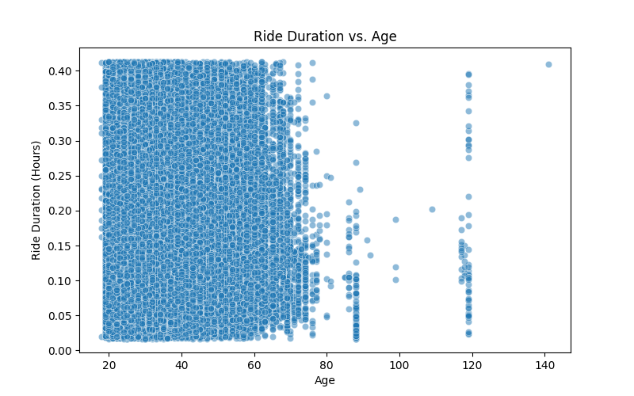

```python
display(Image("Ride Duration vs. Age.png"))
```

Majority of Riders are Below 80 Years Old:

Most data points are concentrated between ages 20 and 80. There are some outliers above 100 years, which might be data entry errors. No Strong Correlation Between Age and Ride Duration:

Ride durations are spread evenly across all age groups, suggesting age does not strongly impact ride duration. The distribution is dense below 0.25 hours (15 minutes). Possible Data Entry Issues for Older Riders:

A few individuals above 100 years old have recorded rides, which is unlikely in real-world scenarios. These may be due to incorrect age entries in the dataset.

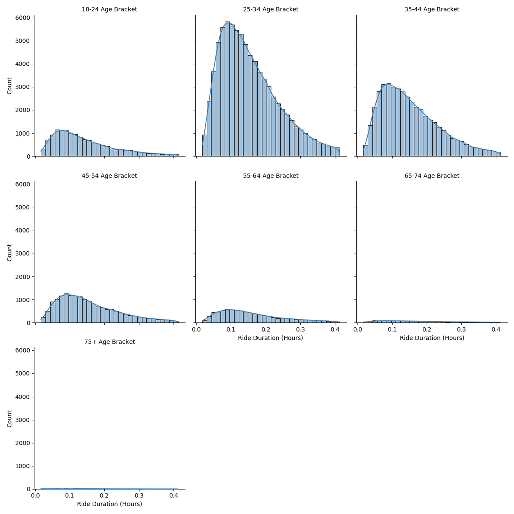

```python
display(Image("Ride Duration Distribution Across Age Brackets.png"))
```

Peak Ride Duration by Age Bracket:

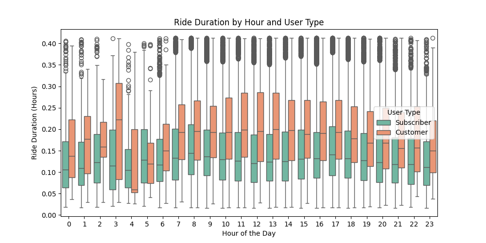

```python
display(Image("Ride Duration by Hour and User Type.png"))
```

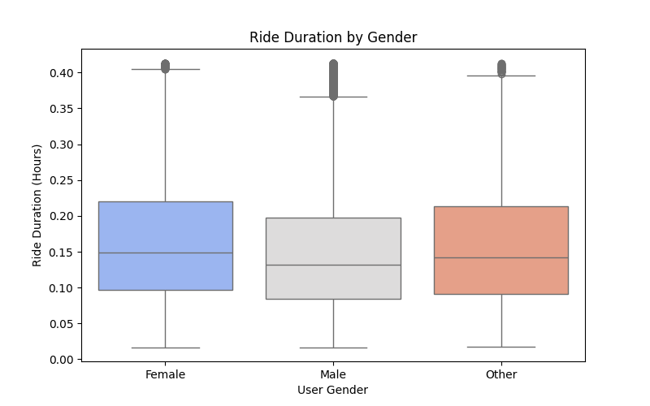

```python
display(Image("Ride Duration by Gender.png"))
```

Most ride durations are below 0.25 hours (~15 minutes). The presence of outliers suggests that some individuals took much longer rides, but these are exceptions. No significant difference in ride duration between genders, meaning gender does not strongly influence ride duration in this dataset.

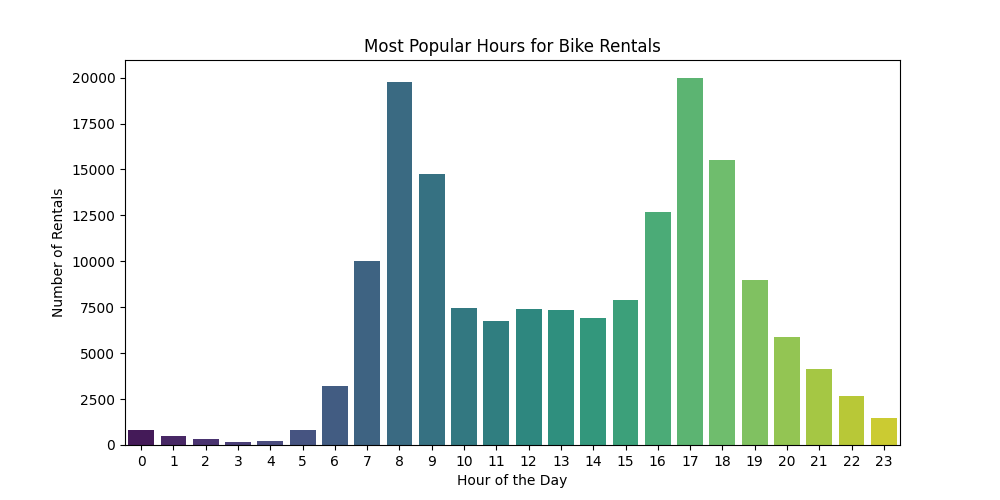

```python
display(Image("Most Popular hours for Bike Rentals.png"))
```

5 pm is the most popular hour to rent a bike

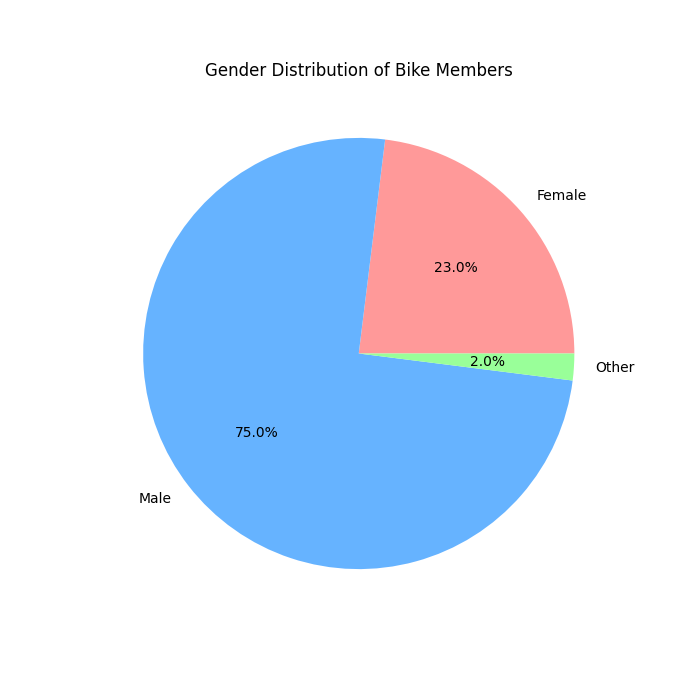

```python
display(Image("Gender Distribution of Bike Members.png"))
```

You should target the male audience much more and try to imprive the feamle audience

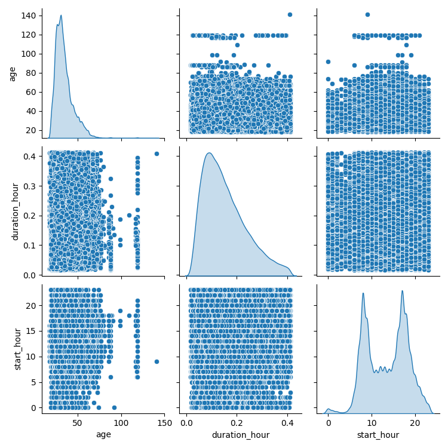

```python
display(Image("age_durationhour_starthour.png"))
```

Age Distribution is Right-Skewed (Top Left Plot) Most riders are young (20-40 years old), with fewer older riders. A few extreme outliers (age 100+) may indicate incorrect or missing data.

Start Hour Shows a Bimodal Distribution (Bottom Right Plot) Two peaks appear around 8 AM and 5-6 PM, likely reflecting commuting hours. This supports the idea that many users rent bikes for work commutes.